# Breaking Bad: Viewership Analysis

Author

Ashutosh Kumar Verma

Published

April 16, 2026

## About the Show

[figure not shown]

Breaking Bad title card — AMC (2008–2013)

*Breaking Bad* is an American crime drama television series created by *Vince Gilligan* that aired on *AMC* from January 20, 2008, to September 29, 2013. The series follows *Walter White* (Bryan Cranston), a struggling high-school chemistry teacher in Albuquerque, New Mexico, who is diagnosed with inoperable lung cancer. Together with his former student *Jesse Pinkman* (Aaron Paul), he enters the world of illegal drug manufacturing and distribution to secure his family’s financial future.

The show ran for **five seasons** and **62 episodes** in total. It received widespread critical acclaim, with particular praise for its writing, directing, and performances. *Breaking Bad* is frequently cited as one of the greatest television series ever made and holds a record-breaking run on *Guinness World Records* as the most critically acclaimed TV show.

## Viewership Data

The viewership figures below are sourced from Wikipedia’s episode lists for *Breaking Bad*. Season averages are calculated from per-episode U.S. live and same-day ratings (millions of viewers).

### Summary Statistics by Season

Breaking Bad U.S. viewership by season (millions of viewers, live + same-day)

[output not shown]

Key descriptive statistics across all seasons:

Descriptive statistics — U.S. viewership across all 62 episodes

| Statistic | Value |
| --- | --- |
| Mean viewership (all episodes) | 2.59M |
| Median viewership | 1.8M |
| Minimum viewership | 1.23M |
| Maximum viewership | 10.28M |
| Standard deviation | 2.11M |

## Viewership Over Time

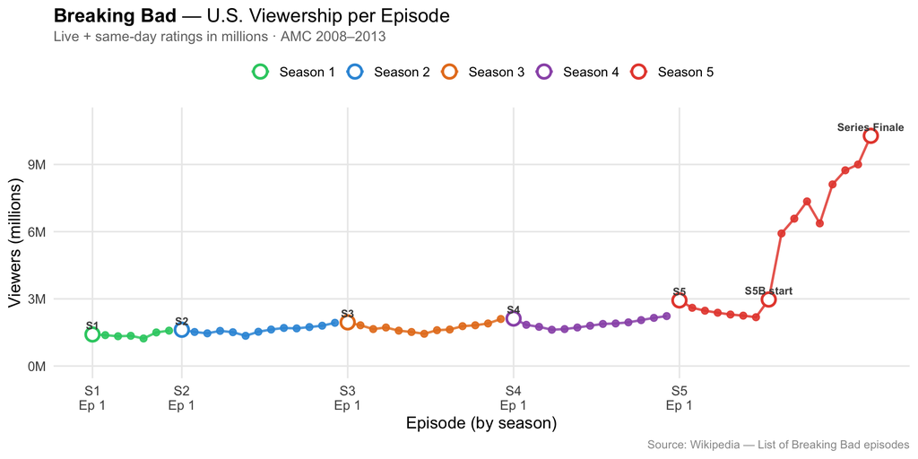

## Episode-to-Episode Changes in Viewership

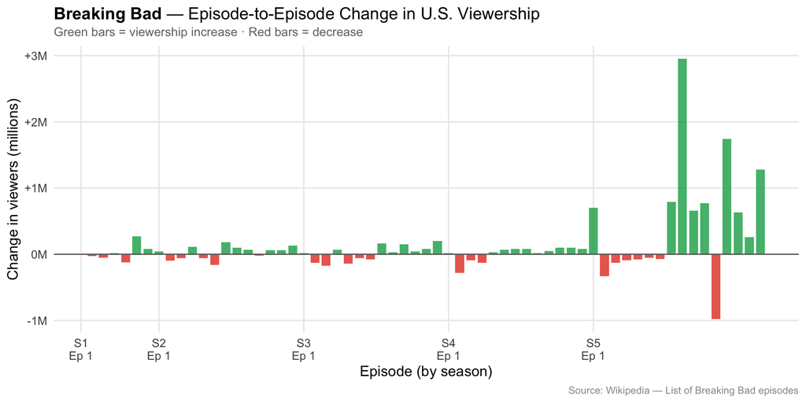

## Key Observations

*Breaking Bad* began its run as a modest cable drama and ended as a cultural phenomenon. Several patterns stand out:

The data tell a story of a slow-burn classic that found its mass audience only in its final stretch — largely fuelled by binge-watching on Netflix, which introduced millions of new viewers to the show just months before the final episodes aired.

*Data sourced from Wikipedia: [List of Breaking Bad episodes](https://en.wikipedia.org/wiki/List_of_Breaking_Bad_episodes).*